# Assignment_9

2023-11-06

loading packages

```r
library(tidyverse)
library(janitor)
library(easystats)
library(GGally)
library(modelr)
library(MASS)
```

# First I read the csv into a data frame and made the admit column logical.

```r
df <- read_csv("C:/Users/18017/Desktop/Data_Course_Nilson/Data/GradSchool_Admissions.csv")
df<- df%>%
  mutate(admit = as.logical(admit))
df
```

```
## # A tibble: 400 × 4
##    admit   gre   gpa  rank
##    <lgl> <dbl> <dbl> <dbl>
##  1 FALSE   380  3.61     3
##  2 TRUE    660  3.67     3
##  3 TRUE    800  4        1
##  4 TRUE    640  3.19     4
##  5 FALSE   520  2.93     4
##  6 TRUE    760  3        2
##  7 TRUE    560  2.98     1
##  8 FALSE   400  3.08     2
##  9 TRUE    540  3.39     3
## 10 FALSE   700  3.92     2
## # ℹ 390 more rows
```

# Now lets take a look at the data

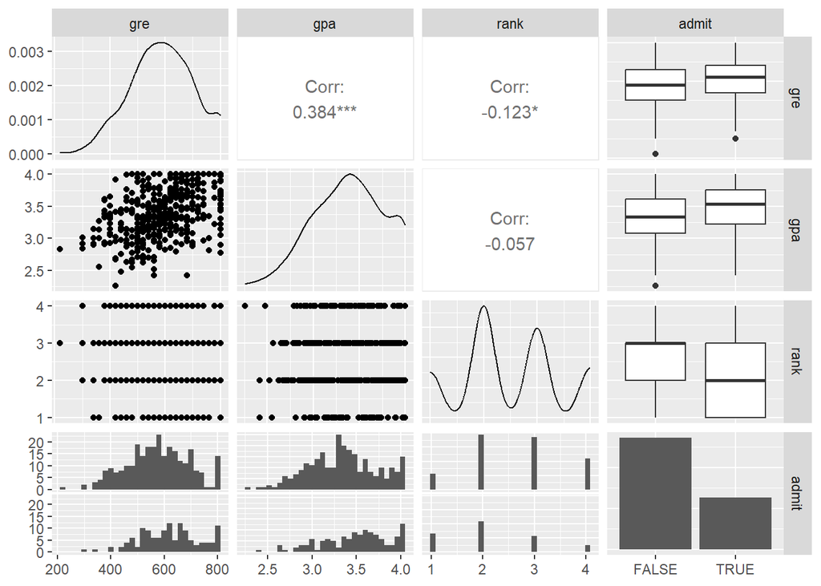

```r
df %>%
  dplyr::select(gre,gpa,rank,admit) %>%
  ggpairs()
```

Clearly each column plays a role in whether the person was admitted to grad school. There are probably other factors as well but I’ll just be exploring these 3.

# Now I’ll make a few models considering each of the factors to analyze and then get the best model

```r
m1<- glm(data = df,
          formula = admit ~ gre,
          family = 'binomial')
m2<- glm(data = df,
          formula = admit ~ gpa,
          family = 'binomial')
m3<- glm(data = df,
          formula = admit ~ rank,
          family = 'binomial')
m4<- glm(data = df,
          formula = admit ~ gre +gpa,
          family = 'binomial')
m5 <- glm(data = df,
          formula = admit ~ gre +gpa +rank,
          family = 'binomial')
m6 <- glm(data = df,
          formula = admit ~ gre*gpa*rank,
          family = 'binomial')
```

# Now I’ll use stepAIC to get the most ideal formula from the complicated m6

```r
step <- stepAIC(m6)
```

```
## Start:  AIC=472.25
## admit ~ gre * gpa * rank
##
##                Df Deviance    AIC
## - gre:gpa:rank  1   456.25 470.25
## <none>              456.25 472.25
##
## Step:  AIC=470.25
## admit ~ gre + gpa + rank + gre:gpa + gre:rank + gpa:rank
##
##            Df Deviance    AIC
## - gre:rank  1   456.34 468.34
## - gpa:rank  1   456.58 468.58
## <none>          456.25 470.25
## - gre:gpa   1   459.31 471.31
##
## Step:  AIC=468.34
## admit ~ gre + gpa + rank + gre:gpa + gpa:rank
##
##            Df Deviance    AIC
## - gpa:rank  1   456.60 466.60
## <none>          456.34 468.34
## - gre:gpa   1   459.33 469.33
##
## Step:  AIC=466.6
## admit ~ gre + gpa + rank + gre:gpa
##
##           Df Deviance    AIC
## <none>         456.60 466.60
## - gre:gpa  1   459.44 467.44
## - rank     1   477.85 485.85
```

```r
step$formula
```

```
## admit ~ gre + gpa + rank + gre:gpa
```

```r
mbest<-glm(data = df,
           formula = step$formula)
```

# Then I’ll compare the performance of each of these models using the *performance* package

```r
compare <- compare_performance(m1,m2,m3,m4,m5,m6,mbest,
                    rank=TRUE)
compare
```

```
## # Comparison of Model Performance Indices
##
## Name  | Model |  RMSE | Sigma | AIC weights | AICc weights | BIC weights | Performance-Score
## --------------------------------------------------------------------------------------------
## m5    |   glm | 0.442 | 1.077 |       0.915 |        0.925 |       0.894 |            78.52%
## mbest |   glm | 0.442 | 0.445 |    1.71e-06 |     1.63e-06 |    3.08e-08 |            37.52%
## m6    |   glm | 0.440 | 1.079 |       0.083 |        0.073 |    2.76e-05 |            24.21%
## m3    |   glm | 0.451 | 1.093 |       0.002 |        0.002 |       0.105 |            10.35%
## m4    |   glm | 0.455 | 1.100 |    7.19e-05 |     7.42e-05 |    5.17e-04 |             3.68%
## m1    |   glm | 0.458 | 1.105 |    1.12e-05 |     1.18e-05 |    5.94e-04 |             0.21%
## m2    |   glm | 0.458 | 1.106 |    7.13e-06 |     7.46e-06 |    3.77e-04 |         8.68e-03%
```

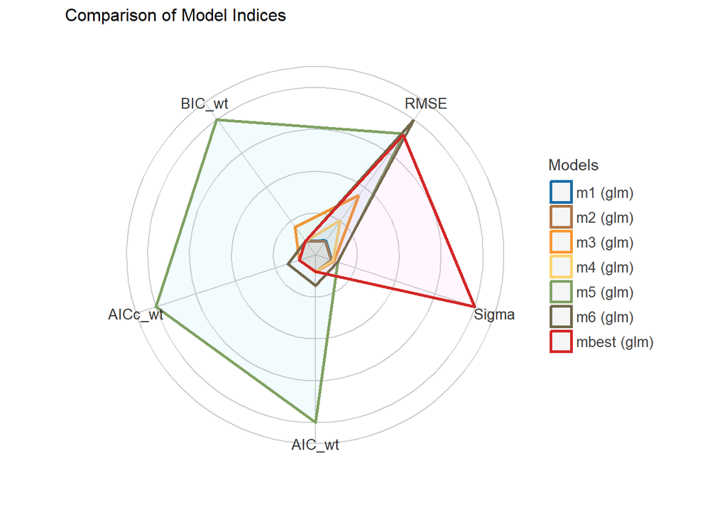

```r
# and a plot of that table
compare %>% plot()
```

From the comparison it seems that the simpler M5 is actually the most ideal and not the stepAIC generated mbest, so we’ll use m5 for predictions.

Now lets add the predictors from m5 and plot it

```r
add_predictions(df,m5,type='response')
```

```
## # A tibble: 400 × 5
##    admit   gre   gpa  rank   pred
##    <lgl> <dbl> <dbl> <dbl>  <dbl>
##  1 FALSE   380  3.61     3 0.190
##  2 TRUE    660  3.67     3 0.318
##  3 TRUE    800  4        1 0.718
##  4 TRUE    640  3.19     4 0.149
##  5 FALSE   520  2.93     4 0.0980
##  6 TRUE    760  3        2 0.379
##  7 TRUE    560  2.98     1 0.399
##  8 FALSE   400  3.08     2 0.221
##  9 TRUE    540  3.39     3 0.222
## 10 FALSE   700  3.92     2 0.521
## # ℹ 390 more rows
```

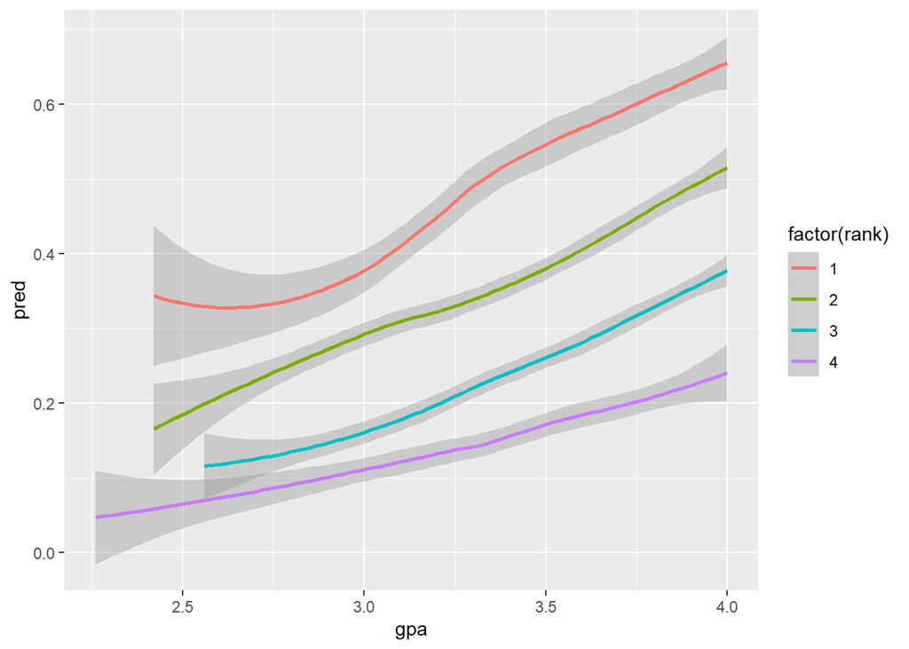

```r
add_predictions(df,m5,type='response')  %>%
  ggplot(aes(x=gpa,y=pred,color=factor(rank))) +
  geom_smooth()
```

This plot shows the percentage likelihood that someone will be accepted into grad school based of our model predictor and shows the rank and gpa.